# Intro to the tidyverse

Richard Rentrop

9/24/2017

## Introduction to the tidyverse

> The tidyverse is an opinionated collection of R packages designed for data science. All packages share an underlying philosophy and common APIs.

> – [tidyverse.org](https://www.tidyverse.org/)

## Loading the tidyverse

To load the tidyverse like any other package via `library`

```r
library(tidyverse)
```

By default the following Packages are loaded:

- ggplot2 - Data visualisation
- tibble - Improved data.frame implementation
- tidyr - Tidy data + spread/gather functions
- readr - Read flat files (csv, tsv, fwf)
- purrr - Functional programming - incl. an improved *apply implementation
- dplyr - Data manipulation

## The pipe `%>%`

Before we start we introduce the pipe operator `%>%` - see https://github.com/tidyverse/magrittr

This operator takes the left hand side and *plugs* it into the right hand side as first argument.

- `f(x)` equivalent to `x %>% f()`
- `f(x, y)` is equivalent to `x %>% f(y)`
- `h(g(f(x)))` is equivalent to `x %>% f %>% g %>% h`

This operator makes the code much more readable as we will see throughout this presentation.

The pipe `%>%` can also be used with an argument placeholder `.` * `f(y, x)` is equivalent to `x %>% f(y, .)` * `f(y, z = x)` is equivalent to `x %>% f(y, z = .)`

And you can reuse the placeholder for attributes:

- `f(x, y = nrow(x), z = ncol(x))` is equivalent to `x %>% f(y = nrow(.), z = ncol(.))`

This can be overruled by enclosing curly brackets `{}`:

- `f(y = nrow(x), z = ncol(x))` is equivalent to `x %>% {f(y = nrow(.), z = ncol(.))}`

Easy example are:

```r
iris %>% head # head(iris)
```

```
##   Sepal.Length Sepal.Width Petal.Length Petal.Width Species
## 1          5.1         3.5          1.4         0.2  setosa
## 2          4.9         3.0          1.4         0.2  setosa
## 3          4.7         3.2          1.3         0.2  setosa
## 4          4.6         3.1          1.5         0.2  setosa
## 5          5.0         3.6          1.4         0.2  setosa
## 6          5.4         3.9          1.7         0.4  setosa
```

```r
c(1, 4, 9, 16, 25) %>% sqrt # sqrt(c(1, 4, 9, 16, 25))
```

```
## [1] 1 2 3 4 5
```

```r
1:10 %>% paste0(LETTERS[.]) # paste0(1:10, LETTERS[1:10])
```

```
##  [1] "1A"  "2B"  "3C"  "4D"  "5E"  "6F"  "7G"  "8H"  "9I"  "10J"
```

All of the functions in the tidyverse are written to be `pipeable`

## Importing data

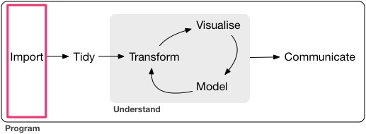

Flow of a typical data science project - source: http://r4ds.had.co.nz/introduction.html

Lots of data science projects stark with a given dataset you want to analyse.

In this presentation we are goint to analyse a given csv (comma seperated values) file `pokemon_raw.csv` with Pokemon stats.

If your data is saved in a database use [`dbplyr`](https://github.com/tidyverse/dbplyr), it is the tidyverse database backend (e.g. for MySQL/MariaDB, Postgresql and SQLite).

To load data into **R** you can use the `read_csv` (with an underscore) function as follows:

```r
# The first column is a comment => skip = 1
read_csv("dat/pokemon_raw.csv", skip = 1)
```

```
## # A tibble: 802 x 17
##       german                              path    rn            generation
##        <chr>                             <chr> <int>                 <chr>
##  1   Bisasam   https://www.pokewiki.de/Bisasam     1 1. Generation‍
##  2 Bisaknosp https://www.pokewiki.de/Bisaknosp     2 1. Generation‍
##  3  Bisaflor  https://www.pokewiki.de/Bisaflor     3 1. Generation‍
##  4  Glumanda  https://www.pokewiki.de/Glumanda     4 1. Generation‍
##  5   Glutexo   https://www.pokewiki.de/Glutexo     5 1. Generation‍
##  6    Glurak    https://www.pokewiki.de/Glurak     6 1. Generation‍
##  7   Schiggy   https://www.pokewiki.de/Schiggy     7 1. Generation‍
##  8  Schillok  https://www.pokewiki.de/Schillok     8 1. Generation‍
##  9    Turtok    https://www.pokewiki.de/Turtok     9 1. Generation‍
## 10     Raupy     https://www.pokewiki.de/Raupy    10 1. Generation‍
## # ... with 792 more rows, and 13 more variables: color <chr>,
## #   english <chr>, ep_to_100 <chr>, gender <chr>, size <chr>, types <chr>,
## #   weight <chr>, attack <int>, speed <int>, hp <int>,
## #   attack_special <int>, defense_special <int>, defense <int>
```

> Specify the col_types explicitly: To make your research reproduciable

```r
read_csv("dat/pokemon_raw.csv",
         skip = 1,
         col_types = cols(
           german = col_character(),
           path = col_character(),
           rn = col_integer(),
           generation = col_character(),
           color = col_character(),
           english = col_character(),
           ep_to_100 = col_character(),
           gender = col_character(),
           size = col_character(),
           types = col_character(),
           weight = col_character(),
           attack = col_integer(),
           speed = col_integer(),
           hp = col_integer(),
           attack_special = col_integer(),
           defense_special = col_integer(),
           defense = col_integer()
        )
)
```

```
## # A tibble: 802 x 17
##       german                              path    rn            generation
##        <chr>                             <chr> <int>                 <chr>
##  1   Bisasam   https://www.pokewiki.de/Bisasam     1 1. Generation‍
##  2 Bisaknosp https://www.pokewiki.de/Bisaknosp     2 1. Generation‍
##  3  Bisaflor  https://www.pokewiki.de/Bisaflor     3 1. Generation‍
##  4  Glumanda  https://www.pokewiki.de/Glumanda     4 1. Generation‍
##  5   Glutexo   https://www.pokewiki.de/Glutexo     5 1. Generation‍
##  6    Glurak    https://www.pokewiki.de/Glurak     6 1. Generation‍
##  7   Schiggy   https://www.pokewiki.de/Schiggy     7 1. Generation‍
##  8  Schillok  https://www.pokewiki.de/Schillok     8 1. Generation‍
##  9    Turtok    https://www.pokewiki.de/Turtok     9 1. Generation‍
## 10     Raupy     https://www.pokewiki.de/Raupy    10 1. Generation‍
## # ... with 792 more rows, and 13 more variables: color <chr>,
## #   english <chr>, ep_to_100 <chr>, gender <chr>, size <chr>, types <chr>,
## #   weight <chr>, attack <int>, speed <int>, hp <int>,
## #   attack_special <int>, defense_special <int>, defense <int>
```

These default `col_types` assume a US-based number and date format. The column size holdes values like `1,1 m` which is a number with a comma (`,`) as decimal mark. To make `read_csv` read the numbers correctly use the `locale` parameter and `col_number` as follows:

`col_number` drops any non-numeric characters before or after the first number. This also works for the `generation` column.

```r
pokemon <- read_csv("dat/pokemon_raw.csv",
         skip = 1,
         locale = locale(decimal_mark = ",", grouping_mark = "."),
         col_types = cols(
           german = col_character(),
           path = col_character(),
           rn = col_integer(),
           generation = col_number(),
           color = col_character(),
           english = col_character(),
           ep_to_100 = col_number(),
           gender = col_character(),
           size = col_number(),
           types = col_character(),
           weight = col_number(),
           attack = col_integer(),
           speed = col_integer(),
           hp = col_integer(),
           attack_special = col_integer(),
           defense_special = col_integer(),
           defense = col_integer()
        )
)

pokemon
```

```
## # A tibble: 802 x 17
##       german                              path    rn generation color
##        <chr>                             <chr> <int>      <dbl> <chr>
##  1   Bisasam   https://www.pokewiki.de/Bisasam     1          1  Grün
##  2 Bisaknosp https://www.pokewiki.de/Bisaknosp     2          1  Grün
##  3  Bisaflor  https://www.pokewiki.de/Bisaflor     3          1  Grün
##  4  Glumanda  https://www.pokewiki.de/Glumanda     4          1   Rot
##  5   Glutexo   https://www.pokewiki.de/Glutexo     5          1   Rot
##  6    Glurak    https://www.pokewiki.de/Glurak     6          1   Rot
##  7   Schiggy   https://www.pokewiki.de/Schiggy     7          1  Blau
##  8  Schillok  https://www.pokewiki.de/Schillok     8          1  Blau
##  9    Turtok    https://www.pokewiki.de/Turtok     9          1  Blau
## 10     Raupy     https://www.pokewiki.de/Raupy    10          1  Grün
## # ... with 792 more rows, and 12 more variables: english <chr>,
## #   ep_to_100 <dbl>, gender <chr>, size <dbl>, types <chr>, weight <dbl>,
## #   attack <int>, speed <int>, hp <int>, attack_special <int>,
## #   defense_special <int>, defense <int>
```

## Tidying Data

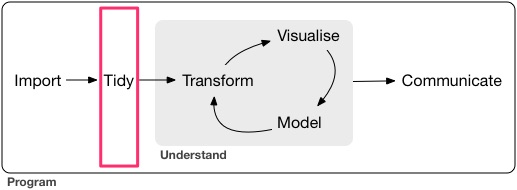

Flow of a typical data science project - source: http://r4ds.had.co.nz/introduction.html

The whole philosophy of tidy data can be found in Hadley Wickham’s “Tidy data” The Journal of Statistical Software, 2014, Volume 59, Issue 10 - http://www.jstatsoft.org/v59/i10/ (accessed 24.9.2017).

In the case of the `pokemon` data-set we only need to seperate the `gender` and the `types` column into multiple columns:

```r
pokemon %>% select(gender, types) # select will be explained later on
```

```
## # A tibble: 802 x 2
##                           gender                             types
##                            <chr>                             <chr>
##  1 87,5% ♂ 12,5% ♀                      Pflanze Gift
##  2 87,5% ♂ 12,5% ♀                      Pflanze Gift
##  3 87,5% ♂ 12,5% ♀                      Pflanze Gift
##  4 87,5% ♂ 12,5% ♀                             Feuer
##  5 87,5% ♂ 12,5% ♀                             Feuer
##  6 87,5% ♂ 12,5% ♀ Feuer Flug  Feuer Drache (Mega X)
##  7 87,5% ♂ 12,5% ♀                            Wasser
##  8 87,5% ♂ 12,5% ♀                            Wasser
##  9 87,5% ♂ 12,5% ♀                            Wasser
## 10     50% ♂ 50% ♀                             Käfer
## # ... with 792 more rows
```

This can easily be done via `seperate` as follows.

```r
pokemon %>%
  select(gender, types) %>% # select will be explained later on
  separate(types, c("type_1", "type_2"), extra = "drop", fill = "right") %>%
  separate(gender, c("male", "female"), extra = "drop", sep = "[^[:alnum:],]+")
```

```
## # A tibble: 802 x 4
##     male female  type_1 type_2
##  * <chr>  <chr>   <chr>  <chr>
##  1  87,5   12,5 Pflanze   Gift
##  2  87,5   12,5 Pflanze   Gift
##  3  87,5   12,5 Pflanze   Gift
##  4  87,5   12,5   Feuer   <NA>
##  5  87,5   12,5   Feuer   <NA>
##  6  87,5   12,5   Feuer   Flug
##  7  87,5   12,5  Wasser   <NA>
##  8  87,5   12,5  Wasser   <NA>
##  9  87,5   12,5  Wasser   <NA>
## 10    50     50   Käfer   <NA>
## # ... with 792 more rows
```

This results in the columns `male` and `female` being type character. Below we will fix this using mutate.

Overwrite pokemon with the new variables as follows:

```r
ncol(pokemon)
```

```
## [1] 17
```

```r
pokemon <- pokemon %>%
  # select(gender, types) %>% # No select this time
  separate(types, c("type_1", "type_2"), extra = "drop", fill = "right") %>%
  separate(gender, c("male", "female"), extra = "drop", sep = "[^[:alnum:],]+")

ncol(pokemon)
```

```
## [1] 19
```

## Transform the data to your needs

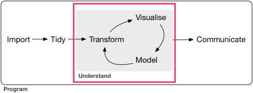

Flow of a typical data science project - source: http://r4ds.had.co.nz/introduction.html

The visualisation part will be done in the other session about `ggplot2`

At the ISI (World Statistics Congress) 2017 Hadley Wickham said:

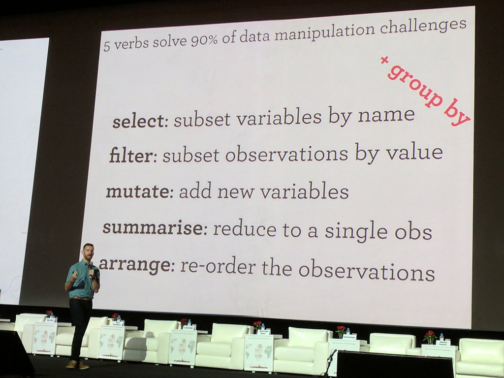

5 verbs solve 90% of data manipulation challenges - source: https://twitter.com/ervance/status/888058950238777344/photo/1

Inside shese verbs you can use the columns of the dataset as if they were variables.

So lets have a look at them

### select

> select() keeps only the variables you mention

We have used `select` once above to select only the `gender` and the `types` column. Lets say we only want to have the name, the hp and size of the pokemon. We can use:

```r
pokemon %>% select(german, english, hp, size)
```

```
## # A tibble: 802 x 4
##       german    english    hp  size
##  *     <chr>      <chr> <int> <dbl>
##  1   Bisasam  Bulbasaur    45   0.7
##  2 Bisaknosp    Ivysaur    60   1.0
##  3  Bisaflor   Venusaur    80   2.0
##  4  Glumanda Charmander    39   0.6
##  5   Glutexo Charmeleon    58   1.1
##  6    Glurak  Charizard    78   1.7
##  7   Schiggy   Squirtle    44   0.5
##  8  Schillok  Wartortle    59   1.0
##  9    Turtok  Blastoise    79   1.6
## 10     Raupy   Caterpie    45   0.3
## # ... with 792 more rows
```

There are some select helpers see `?select_helpers` like `starts_with`:

```r
pokemon %>% select(starts_with("type"))
```

```
## # A tibble: 802 x 2
##     type_1 type_2
##  *   <chr>  <chr>
##  1 Pflanze   Gift
##  2 Pflanze   Gift
##  3 Pflanze   Gift
##  4   Feuer   <NA>
##  5   Feuer   <NA>
##  6   Feuer   Flug
##  7  Wasser   <NA>
##  8  Wasser   <NA>
##  9  Wasser   <NA>
## 10   Käfer   <NA>
## # ... with 792 more rows
```

We can use select to reorder the columns and make sure that we do not drop a variable accidently with `everything()` which selects all not previously selected columns:

```r
pokemon <- pokemon %>%
  select(rn, german, english, color, type_1, type_2, size, weight,
         attack, speed, hp, defense, attack_special, defense_special,
         ep_to_100, male, female, path, everything())

pokemon
```

```
## # A tibble: 802 x 19
##       rn    german    english color  type_1 type_2  size weight attack
##  * <int>     <chr>      <chr> <chr>   <chr>  <chr> <dbl>  <dbl>  <int>
##  1     1   Bisasam  Bulbasaur  Grün Pflanze   Gift   0.7    6.9     49
##  2     2 Bisaknosp    Ivysaur  Grün Pflanze   Gift   1.0   13.0     62
##  3     3  Bisaflor   Venusaur  Grün Pflanze   Gift   2.0  100.0     82
##  4     4  Glumanda Charmander   Rot   Feuer   <NA>   0.6    8.5     52
##  5     5   Glutexo Charmeleon   Rot   Feuer   <NA>   1.1   19.0     64
##  6     6    Glurak  Charizard   Rot   Feuer   Flug   1.7   90.5     84
##  7     7   Schiggy   Squirtle  Blau  Wasser   <NA>   0.5    9.0     48
##  8     8  Schillok  Wartortle  Blau  Wasser   <NA>   1.0   22.5     63
##  9     9    Turtok  Blastoise  Blau  Wasser   <NA>   1.6   85.5     83
## 10    10     Raupy   Caterpie  Grün   Käfer   <NA>   0.3    2.9     30
## # ... with 792 more rows, and 10 more variables: speed <int>, hp <int>,
## #   defense <int>, attack_special <int>, defense_special <int>,
## #   ep_to_100 <dbl>, male <chr>, female <chr>, path <chr>,
## #   generation <dbl>
```

To select all columns but a specific one use `-var`. `pokemon %>% select(-rn)` drops the rn column.

#### Exercise

- Select only the Pokemon names (german and english)
- Select the names, attack, speed and size
- Select all variables that `ends_with` “attack”

### filter

To filter the dataset use the `filter` verb. Lets say we just want pokemon from generation 1 we can use:

```r
pokemon %>% filter(generation == 1)
```

```
## # A tibble: 151 x 19
##       rn    german    english color  type_1 type_2  size weight attack
##    <int>     <chr>      <chr> <chr>   <chr>  <chr> <dbl>  <dbl>  <int>
##  1     1   Bisasam  Bulbasaur  Grün Pflanze   Gift   0.7    6.9     49
##  2     2 Bisaknosp    Ivysaur  Grün Pflanze   Gift   1.0   13.0     62
##  3     3  Bisaflor   Venusaur  Grün Pflanze   Gift   2.0  100.0     82
##  4     4  Glumanda Charmander   Rot   Feuer   <NA>   0.6    8.5     52
##  5     5   Glutexo Charmeleon   Rot   Feuer   <NA>   1.1   19.0     64
##  6     6    Glurak  Charizard   Rot   Feuer   Flug   1.7   90.5     84
##  7     7   Schiggy   Squirtle  Blau  Wasser   <NA>   0.5    9.0     48
##  8     8  Schillok  Wartortle  Blau  Wasser   <NA>   1.0   22.5     63
##  9     9    Turtok  Blastoise  Blau  Wasser   <NA>   1.6   85.5     83
## 10    10     Raupy   Caterpie  Grün   Käfer   <NA>   0.3    2.9     30
## # ... with 141 more rows, and 10 more variables: speed <int>, hp <int>,
## #   defense <int>, attack_special <int>, defense_special <int>,
## #   ep_to_100 <dbl>, male <chr>, female <chr>, path <chr>,
## #   generation <dbl>
```

This results in the well known 151 pokemon from the original Game Boy games.

You can combine filters with AND `&` and OR `|`. A filter expects a logical vector of the same length as the data:

```r
pokemon %>% filter(generation == 1 & color == "Rot")
```

```
## # A tibble: 16 x 19
##       rn    german    english color  type_1  type_2  size weight attack
##    <int>     <chr>      <chr> <chr>   <chr>   <chr> <dbl>  <dbl>  <int>
##  1     4  Glumanda Charmander   Rot   Feuer    <NA>   0.6    8.5     52
##  2     5   Glutexo Charmeleon   Rot   Feuer    <NA>   1.1   19.0     64
##  3     6    Glurak  Charizard   Rot   Feuer    Flug   1.7   90.5     84
##  4    45    Giflor  Vileplume   Rot Pflanze    Gift   1.2   18.6     80
##  5    46     Paras      Paras   Rot   Käfer Pflanze   0.3    5.4     70
##  6    47   Parasek   Parasect   Rot   Käfer Pflanze   1.0   29.5     95
##  7    98    Krabby     Krabby   Rot  Wasser    <NA>   0.4    6.5    105
##  8    99   Kingler    Kingler   Rot  Wasser    <NA>   1.3   60.0    130
##  9   100  Voltobal    Voltorb   Rot Elektro    <NA>   0.5   10.4     30
## 10   101 Lektrobal  Electrode   Rot Elektro    <NA>   1.2   66.6     50
## 11   118   Goldini    Goldeen   Rot  Wasser    <NA>   0.6   15.0     67
## 12   119   Golking    Seaking   Rot  Wasser    <NA>   1.3   39.0     92
## 13   124   Rossana       Jynx   Rot     Eis  Psycho   1.4   40.6     50
## 14   126    Magmar     Magmar   Rot   Feuer    <NA>   1.3   44.5     95
## 15   129  Karpador   Magikarp   Rot  Wasser    <NA>   0.9   10.0     10
## 16   136   Flamara    Flareon   Rot   Feuer    <NA>   0.9   25.0    130
## # ... with 10 more variables: speed <int>, hp <int>, defense <int>,
## #   attack_special <int>, defense_special <int>, ep_to_100 <dbl>,
## #   male <chr>, female <chr>, path <chr>, generation <dbl>
```

```r
pokemon %>% filter(color == "Rot" | color == "Grün")
```

```
## # A tibble: 167 x 19
##       rn    german    english color  type_1  type_2  size weight attack
##    <int>     <chr>      <chr> <chr>   <chr>   <chr> <dbl>  <dbl>  <int>
##  1     1   Bisasam  Bulbasaur  Grün Pflanze    Gift   0.7    6.9     49
##  2     2 Bisaknosp    Ivysaur  Grün Pflanze    Gift   1.0   13.0     62
##  3     3  Bisaflor   Venusaur  Grün Pflanze    Gift   2.0  100.0     82
##  4     4  Glumanda Charmander   Rot   Feuer    <NA>   0.6    8.5     52
##  5     5   Glutexo Charmeleon   Rot   Feuer    <NA>   1.1   19.0     64
##  6     6    Glurak  Charizard   Rot   Feuer    Flug   1.7   90.5     84
##  7    10     Raupy   Caterpie  Grün   Käfer    <NA>   0.3    2.9     30
##  8    11    Safcon    Metapod  Grün   Käfer    <NA>   0.7    9.9     20
##  9    45    Giflor  Vileplume   Rot Pflanze    Gift   1.2   18.6     80
## 10    46     Paras      Paras   Rot   Käfer Pflanze   0.3    5.4     70
## # ... with 157 more rows, and 10 more variables: speed <int>, hp <int>,
## #   defense <int>, attack_special <int>, defense_special <int>,
## #   ep_to_100 <dbl>, male <chr>, female <chr>, path <chr>,
## #   generation <dbl>
```

```r
# the above is equivalent to
pokemon %>% filter(color %in% c("Rot", "Grün"))
```

```
## # A tibble: 167 x 19
##       rn    german    english color  type_1  type_2  size weight attack
##    <int>     <chr>      <chr> <chr>   <chr>   <chr> <dbl>  <dbl>  <int>
##  1     1   Bisasam  Bulbasaur  Grün Pflanze    Gift   0.7    6.9     49
##  2     2 Bisaknosp    Ivysaur  Grün Pflanze    Gift   1.0   13.0     62
##  3     3  Bisaflor   Venusaur  Grün Pflanze    Gift   2.0  100.0     82
##  4     4  Glumanda Charmander   Rot   Feuer    <NA>   0.6    8.5     52
##  5     5   Glutexo Charmeleon   Rot   Feuer    <NA>   1.1   19.0     64
##  6     6    Glurak  Charizard   Rot   Feuer    Flug   1.7   90.5     84
##  7    10     Raupy   Caterpie  Grün   Käfer    <NA>   0.3    2.9     30
##  8    11    Safcon    Metapod  Grün   Käfer    <NA>   0.7    9.9     20
##  9    45    Giflor  Vileplume   Rot Pflanze    Gift   1.2   18.6     80
## 10    46     Paras      Paras   Rot   Käfer Pflanze   0.3    5.4     70
## # ... with 157 more rows, and 10 more variables: speed <int>, hp <int>,
## #   defense <int>, attack_special <int>, defense_special <int>,
## #   ep_to_100 <dbl>, male <chr>, female <chr>, path <chr>,
## #   generation <dbl>
```

#### Exercise

- Filter for Pokemon that do not have a gender (`male` is NA)
- How many Pokemon do only have one type?
- Filter for Pokemon with the same name in English and German from generation 1 and type_1 == gift

### mutate

Mutate lets you edit or create columns in your data.

The above created columns `male` and `female` are of type `character`. To fix this we can do:

```r
pokemon <- pokemon %>%
  mutate(
    male = parse_number(male, locale = locale(decimal_mark = ",")),
    female = parse_number(female, locale = locale(decimal_mark = ","))
  )

pokemon %>%
  select(male, female)
```

```
## # A tibble: 802 x 2
##     male female
##    <dbl>  <dbl>
##  1  87.5   12.5
##  2  87.5   12.5
##  3  87.5   12.5
##  4  87.5   12.5
##  5  87.5   12.5
##  6  87.5   12.5
##  7  87.5   12.5
##  8  87.5   12.5
##  9  87.5   12.5
## 10  50.0   50.0
## # ... with 792 more rows
```

This overwrites the columns in place.

To add a new variable we can also `mutate` as follows:

```r
pokemon <- pokemon %>% mutate(dual_type = !is.na(type_2))

pokemon %>% select(german, english, type_1, type_2, dual_type)
```

```
## # A tibble: 802 x 5
##       german    english  type_1 type_2 dual_type
##        <chr>      <chr>   <chr>  <chr>     <lgl>
##  1   Bisasam  Bulbasaur Pflanze   Gift      TRUE
##  2 Bisaknosp    Ivysaur Pflanze   Gift      TRUE
##  3  Bisaflor   Venusaur Pflanze   Gift      TRUE
##  4  Glumanda Charmander   Feuer   <NA>     FALSE
##  5   Glutexo Charmeleon   Feuer   <NA>     FALSE
##  6    Glurak  Charizard   Feuer   Flug      TRUE
##  7   Schiggy   Squirtle  Wasser   <NA>     FALSE
##  8  Schillok  Wartortle  Wasser   <NA>     FALSE
##  9    Turtok  Blastoise  Wasser   <NA>     FALSE
## 10     Raupy   Caterpie   Käfer   <NA>     FALSE
## # ... with 792 more rows
```

#### Exercise

- Compute the difference between attack and defense and name it `diff_att_def`

### arrange

To arrange/order the data so that it is more compelling we can use `arrange`

Lets say we want the pokemon ordered by **hp** we can use:

```r
pokemon %>%
  arrange(hp) %>%
  select(rn, german, english, hp, speed)
```

```
## # A tibble: 802 x 5
##       rn     german   english    hp speed
##    <int>      <chr>     <chr> <int> <int>
##  1   292   Ninjatom  Shedinja     1    40
##  2    50      Digda   Diglett    10    95
##  3   129   Karpador  Magikarp    20    80
##  4   172      Pichu     Pichu    20    60
##  5   213   Pottrott   Shuckle    20     5
##  6   349   Barschwa    Feebas    20    80
##  7   355 Zwirrlicht   Duskull    20    25
##  8   439  Pantimimi  Mime Jr.    20    60
##  9    63       Abra      Abra    25    90
## 10    81  Magnetilo Magnemite    25    45
## # ... with 792 more rows
```

To arrange the data in a descending order, wrap the variable in `desc(.)`. To order by multiple columns just use multiple arguments to arrange:

```r
pokemon %>%
  arrange(hp, desc(speed)) %>%
  select(rn, german, english, hp, speed)
```

```
## # A tibble: 802 x 5
##       rn     german  english    hp speed
##    <int>      <chr>    <chr> <int> <int>
##  1   292   Ninjatom Shedinja     1    40
##  2    50      Digda  Diglett    10    95
##  3   129   Karpador Magikarp    20    80
##  4   349   Barschwa   Feebas    20    80
##  5   172      Pichu    Pichu    20    60
##  6   439  Pantimimi Mime Jr.    20    60
##  7   355 Zwirrlicht  Duskull    20    25
##  8   213   Pottrott  Shuckle    20     5
##  9    63       Abra     Abra    25    90
## 10   767   Reißlaus   Wimpod    25    80
## # ... with 792 more rows
```

### summarise

To condense the information to a single value you can use summarise.

Lets say we want to know the `mean` and the `median` **hp** of all pokemon, we can use:

```r
pokemon %>%
  summarise(
    mean_hp = mean(hp),
    median_hp = median(hp)
    )
```

```
## # A tibble: 1 x 2
##    mean_hp median_hp
##      <dbl>     <dbl>
## 1 68.66584        65
```

### Group By

Lets say we want to know the `mean` **hp** by **generation**. This is where `group_by` comes into play:

```r
pokemon %>%
  group_by(generation) %>%
  summarise(
    mean_hp = mean(hp),
    median_hp = median(hp)
    ) %>%
  mutate(diff_hp = abs(mean_hp - median_hp))
```

```
## # A tibble: 7 x 4
##   generation  mean_hp median_hp   diff_hp
##        <dbl>    <dbl>     <dbl>     <dbl>
## 1          1 64.21192      60.0 4.2119205
## 2          2 70.98000      67.5 3.4800000
## 3          3 65.66667      61.0 4.6666667
## 4          4 73.10280      70.0 3.1028037
## 5          5 70.32051      70.0 0.3205128
## 6          6 67.95833      63.5 4.4583333
## 7          7 70.69136      68.0 2.6913580
```

If we want to know the number of Pokemon per generation we can use the helper `n()` which gives us the group-size:

```r
pokemon %>%
  group_by(generation) %>%
  summarise(n = n())
```

```
## # A tibble: 7 x 2
##   generation     n
##        <dbl> <int>
## 1          1   151
## 2          2   100
## 3          3   135
## 4          4   107
## 5          5   156
## 6          6    72
## 7          7    81
```

Another question might be: Which pokemon has the most **hp** per generation.  
This can be answered by:

```r
pokemon %>%
  group_by(generation) %>%
  filter(hp == max(hp)) %>%
  select(rn, generation, german, english, hp)
```

```
## # A tibble: 9 x 5
## # Groups:   generation [7]
##      rn generation      german   english    hp
##   <int>      <dbl>       <chr>     <chr> <int>
## 1   113          1    Chaneira   Chansey   250
## 2   242          2    Heiteira   Blissey   255
## 3   321          3     Wailord   Wailord   170
## 4   426          4  Drifzepeli  Drifblim   150
## 5   487          4    Giratina  Giratina   150
## 6   594          5    Mamolida Alomomola   165
## 7   716          6     Xerneas   Xerneas   126
## 8   717          6     Yveltal   Yveltal   126
## 9   799          7 Schlingking  Guzzlord   223
```

```r
# Equivalent using arrange
pokemon %>%
  group_by(generation) %>%
  arrange(desc(hp)) %>%
  slice(1L) %>% # select rows by number. Here only the first one.
  select(rn, generation, german, english, hp)
```

```
## # A tibble: 7 x 5
## # Groups:   generation [7]
##      rn generation      german   english    hp
##   <int>      <dbl>       <chr>     <chr> <int>
## 1   113          1    Chaneira   Chansey   250
## 2   242          2    Heiteira   Blissey   255
## 3   321          3     Wailord   Wailord   170
## 4   426          4  Drifzepeli  Drifblim   150
## 5   594          5    Mamolida Alomomola   165
## 6   716          6     Xerneas   Xerneas   126
## 7   799          7 Schlingking  Guzzlord   223
```

Group by also works with `mutate`. Lets say we want to know how much bigger the maximum hp is than the mean hp:

```r
pokemon %>%
  group_by(generation) %>%
  mutate(
    mean_hp = mean(hp),
    hp_normalized = hp - mean_hp
    ) %>%
  filter(hp == max(hp)) %>%
  select(rn, generation, german, english, hp, mean_hp, hp_normalized)
```

```
## # A tibble: 9 x 7
## # Groups:   generation [7]
##      rn generation      german   english    hp  mean_hp hp_normalized
##   <int>      <dbl>       <chr>     <chr> <int>    <dbl>         <dbl>
## 1   113          1    Chaneira   Chansey   250 64.21192     185.78808
## 2   242          2    Heiteira   Blissey   255 70.98000     184.02000
## 3   321          3     Wailord   Wailord   170 65.66667     104.33333
## 4   426          4  Drifzepeli  Drifblim   150 73.10280      76.89720
## 5   487          4    Giratina  Giratina   150 73.10280      76.89720
## 6   594          5    Mamolida Alomomola   165 70.32051      94.67949
## 7   716          6     Xerneas   Xerneas   126 67.95833      58.04167
## 8   717          6     Yveltal   Yveltal   126 67.95833      58.04167
## 9   799          7 Schlingking  Guzzlord   223 70.69136     152.30864
```

Excercise:

- Which Pokemon has the highest `speed` per `type_1`?
- How much more/less `attack` do Pokemon with a dual_type have?
- Calculate the mean for all numeric variables per generation. Carefully read the documentation of `summarise_if`
- Count the mostly female (`female` > 50) Pokemon per type_1

## Appendix

Not sure how much time the above will consume, here are some backup things:

### Reading multiple files

Often times you need to read multiple equivalently formatted files into R.

Lets say we would get one csv file per generation. `pokemon_raw_gen_1.csv`, …, `pokemon_raw_gen_7.csv`

```r
poke_files <- list.files("dat/multi-file", full.names = TRUE)
pokemon2 <- map_df(poke_files,
       read_csv,
         locale = locale(decimal_mark = ",", grouping_mark = "."),
         col_types = cols(
           german = col_character(),
           path = col_character(),
           rn = col_integer(),
           generation = col_number(),
           color = col_character(),
           english = col_character(),
           ep_to_100 = col_number(),
           gender = col_character(),
           size = col_number(),
           types = col_character(),
           weight = col_number(),
           attack = col_integer(),
           speed = col_integer(),
           hp = col_integer(),
           attack_special = col_integer(),
           defense_special = col_integer(),
           defense = col_integer()
        )
       )

pokemon2
```

```
## # A tibble: 802 x 17
##       german                              path    rn generation color
##        <chr>                             <chr> <int>      <dbl> <chr>
##  1   Bisasam   https://www.pokewiki.de/Bisasam     1          1  Grün
##  2 Bisaknosp https://www.pokewiki.de/Bisaknosp     2          1  Grün
##  3  Bisaflor  https://www.pokewiki.de/Bisaflor     3          1  Grün
##  4  Glumanda  https://www.pokewiki.de/Glumanda     4          1   Rot
##  5   Glutexo   https://www.pokewiki.de/Glutexo     5          1   Rot
##  6    Glurak    https://www.pokewiki.de/Glurak     6          1   Rot
##  7   Schiggy   https://www.pokewiki.de/Schiggy     7          1  Blau
##  8  Schillok  https://www.pokewiki.de/Schillok     8          1  Blau
##  9    Turtok    https://www.pokewiki.de/Turtok     9          1  Blau
## 10     Raupy     https://www.pokewiki.de/Raupy    10          1  Grün
## # ... with 792 more rows, and 12 more variables: english <chr>,
## #   ep_to_100 <dbl>, gender <chr>, size <dbl>, types <chr>, weight <dbl>,
## #   attack <int>, speed <int>, hp <int>, attack_special <int>,
## #   defense_special <int>, defense <int>
```

### Managing many models

You can use `map` to loop through lists/vectors. One very powerful concept that was introduced in the tidyverse is the nested dataset - https://www.youtube.com/watch?v=rz3_FDVt9eg Lets say we want to build a model how **hp** is dependent on **size**.

For the full dataset we can do this as follows

```r
require(broom) # tidy model parameter
lm(hp ~ size, data = pokemon) %>% tidy
```

```
##          term estimate std.error statistic       p.value
## 1 (Intercept) 55.65832 1.2014963  46.32417 1.164009e-228
## 2        size 11.27909 0.7640831  14.76160  8.632627e-44
```

And now we want to fit the same model per generation. To do this we nest the data as follows:

```r
(pokemon_nested <- nest(pokemon, -generation))
```

```
## # A tibble: 7 x 2
##   generation                data
##        <dbl>              <list>
## 1          1 <tibble [151 x 19]>
## 2          2 <tibble [100 x 19]>
## 3          3 <tibble [135 x 19]>
## 4          4 <tibble [107 x 19]>
## 5          5 <tibble [156 x 19]>
## 6          6  <tibble [72 x 19]>
## 7          7  <tibble [81 x 19]>
```

This way we get a tibble (~data.frame) with all the data of one generation in one list-entry. Now we can model the above using `map` as follows:

```r
pokemon_nested %>%
  mutate(
    mod = map(data, ~lm(hp ~ size, .x)),
    mod_tidy = map(mod, tidy)
  ) %>%
  unnest(mod_tidy)
```

```
## # A tibble: 14 x 6
##    generation        term  estimate std.error statistic      p.value
##         <dbl>       <chr>     <dbl>     <dbl>     <dbl>        <dbl>
##  1          1 (Intercept) 55.577404  3.616135 15.369284 1.536453e-32
##  2          1        size  7.227339  2.360004  3.062427 2.605742e-03
##  3          2 (Intercept) 60.465075  4.384618 13.790271 1.097571e-24
##  4          2        size  9.041208  2.765069  3.269795 1.485610e-03
##  5          3 (Intercept) 53.444624  2.301683 23.219800 1.246024e-48
##  6          3        size  9.939613  1.199690  8.285148 1.117947e-13
##  7          4 (Intercept) 55.916601  3.242325 17.245834 2.095918e-32
##  8          4        size 15.160129  2.250424  6.736565 8.939052e-10
##  9          5 (Intercept) 50.668631  2.808471 18.041356 8.115600e-40
## 10          5        size 19.029755  2.328349  8.173069 1.028488e-13
## 11          6 (Intercept) 53.376488  2.937670 18.169666 3.307216e-28
## 12          6        size 13.706173  2.040727  6.716319 4.092251e-09
## 13          7 (Intercept) 53.073415  3.184980 16.663659 1.399541e-27
## 14          7        size 13.828037  1.707268  8.099513 5.578469e-12
```